# Bengaluru Metro

Ravi Gadepalli

Last compiled: 20 December 2022, 19:26:05

# 1 System-Wide Characteristics

## 1.1 Hourly Pattern:[Cards+Tokens]

### Hourly (Absolute)

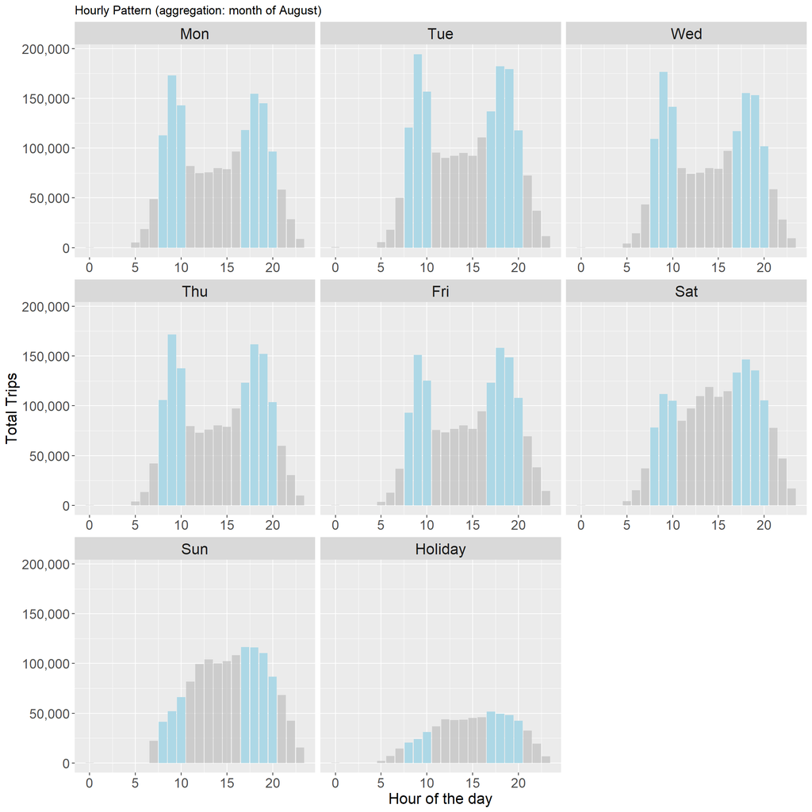

### Hourly (Supply vs Demand)

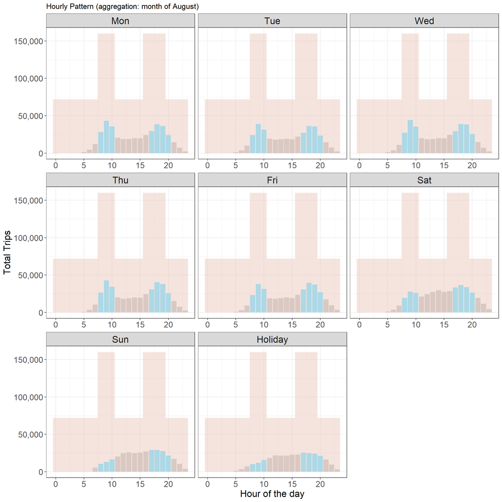

### Hourly (Percentage)

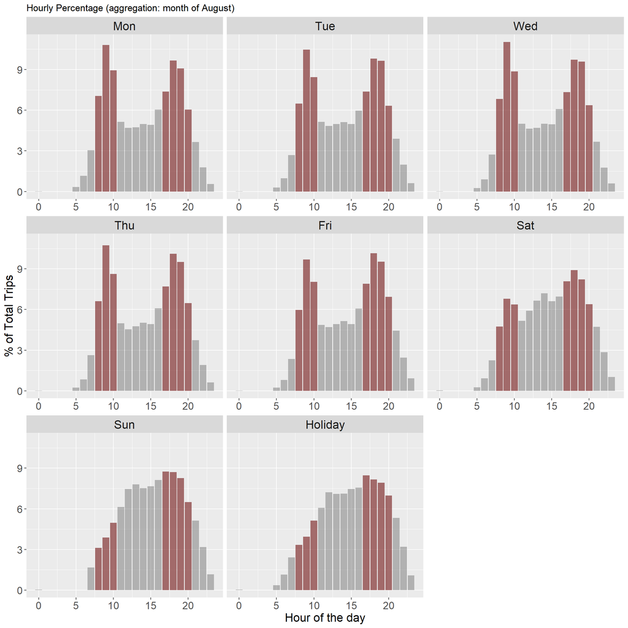

## 1.2 Hourly Pattern: Smart Cards

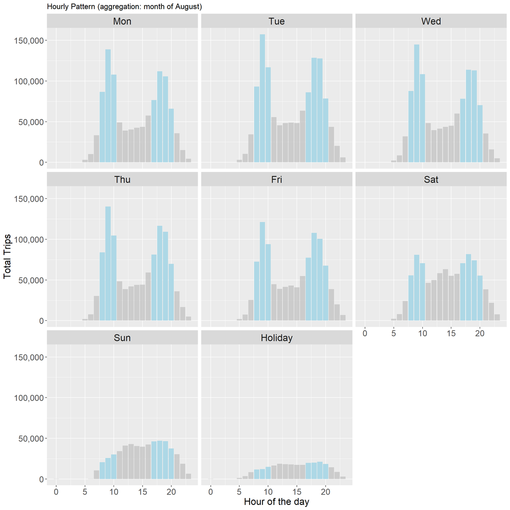

## 1.3 Hourly Pattern: Tokens

The public holidays include Independence Day (15), Ganesh Chaturthi (31).

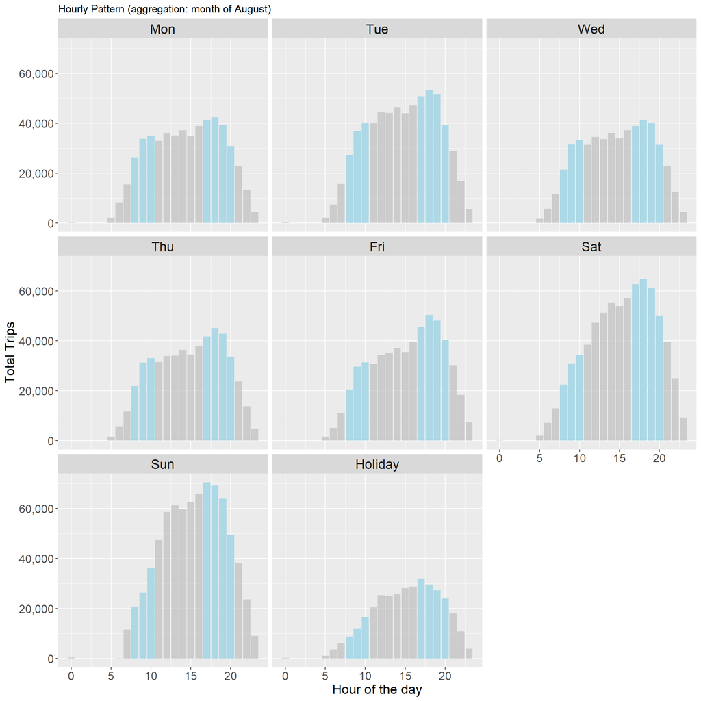

## 1.4 Daily Variation: Peak vs Off Peak (Smart Cards)

Morning Peak is 08:00-10:00 hrs, Evening Peak is 16:00-19:00 hrs

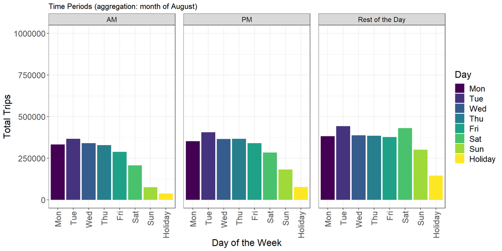

## 1.5 Daily Variation: Peak vs Off Peak (Tokens)

Morning Peak is 08:00-10:00 hrs, Evening Peak is 16:00-19:00 hrs

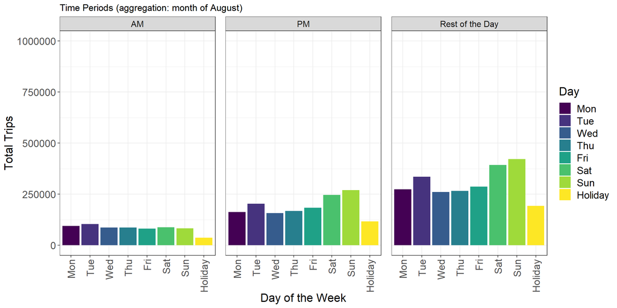

## 1.6 Daily Variation: Peak vs Off Peak (Smart Cards + Tokens)

Morning Peak is 08:00-10:00 hrs, Evening Peak is 16:00-19:00 hrs

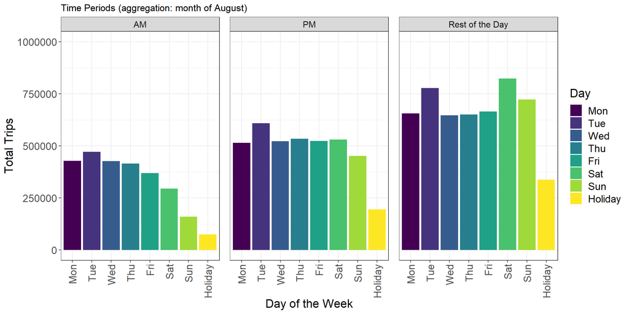

# 2 Capacity Estimates

- Number of pax per car = 500
- Number of cars per train = 6
- Number of pax per train = 3000
- Peak hour frequency in one direction = 4.5 min, trips per hour = 13.3 trips in one-direction
- Peak hour frequency in one direction = 10 min, trips per hour = 6 trips in one-direction
- Peak hour capacity in one direction = 39900 , capacity in two-directions = 79800
- Peak hour capacity in one direction = 18000 , capacity in two-directions = 36000

# 3 Line Based Characteristics - Per Day

Sample Calculation for Monday: Add all trips on all Mondays of the month and divide by number of Mondays in the month.

## 3.1 Hourly Trends: Smart Cards

The public holidays include Independence Day (15), Ganesh Chaturthi (31).

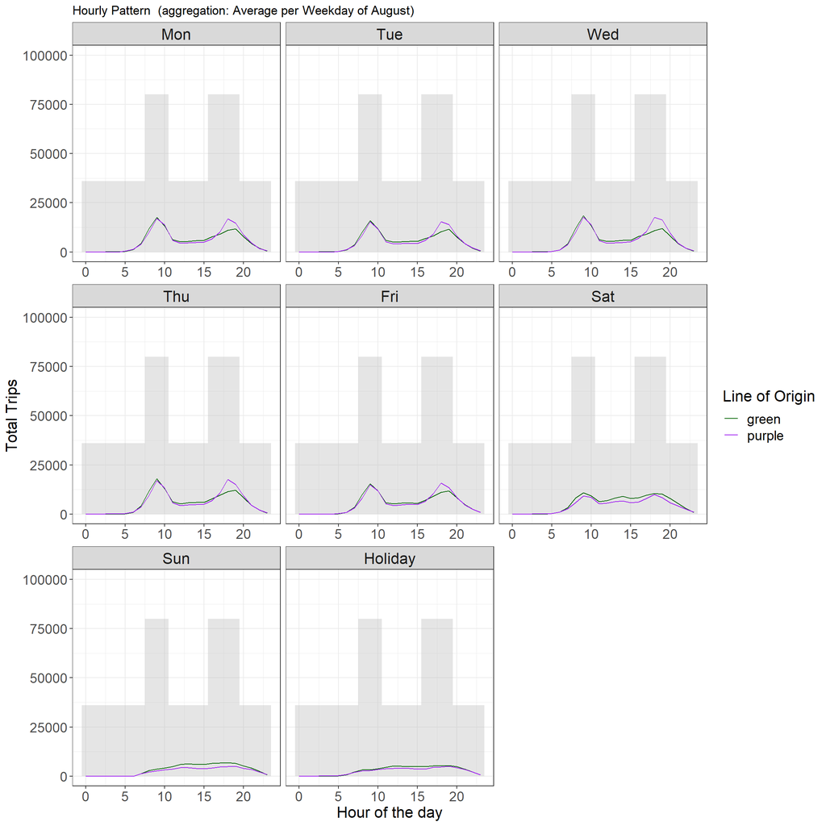

## 3.2 Hourly Trends: Tokens

The public holidays include Independence Day (15), Ganesh Chaturthi (31).

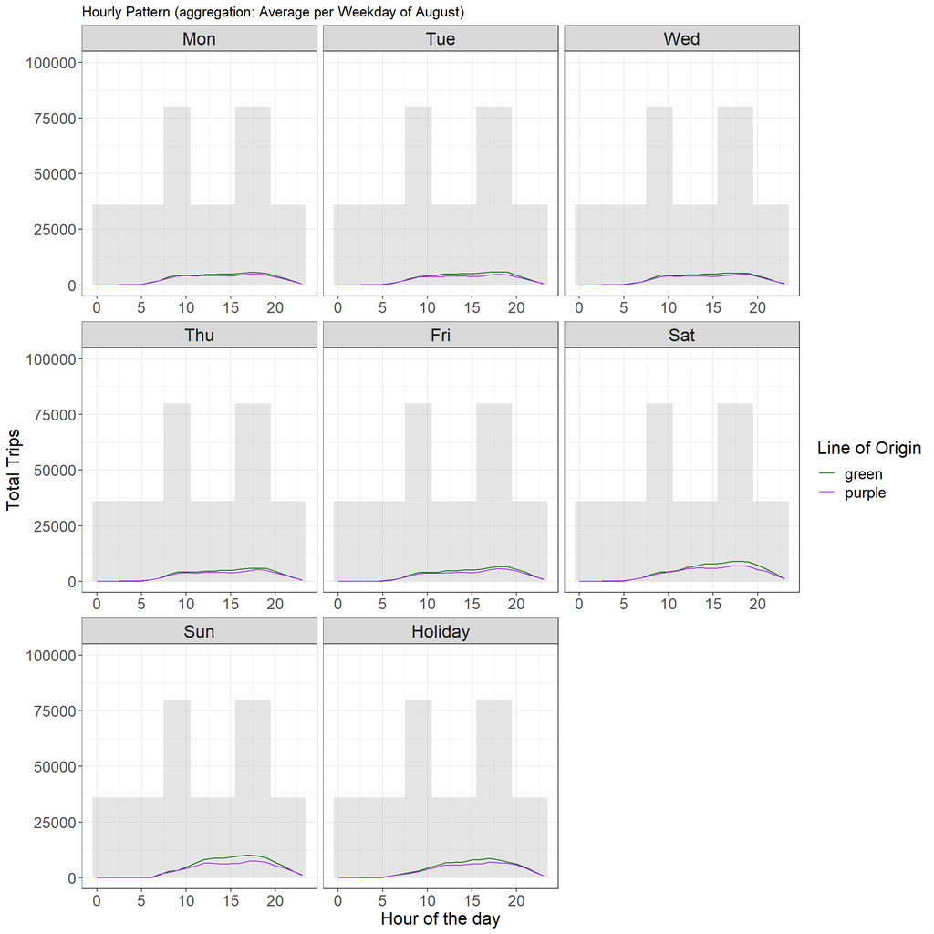

## 3.3 Hourly Trends: Smart Cards + Tokens

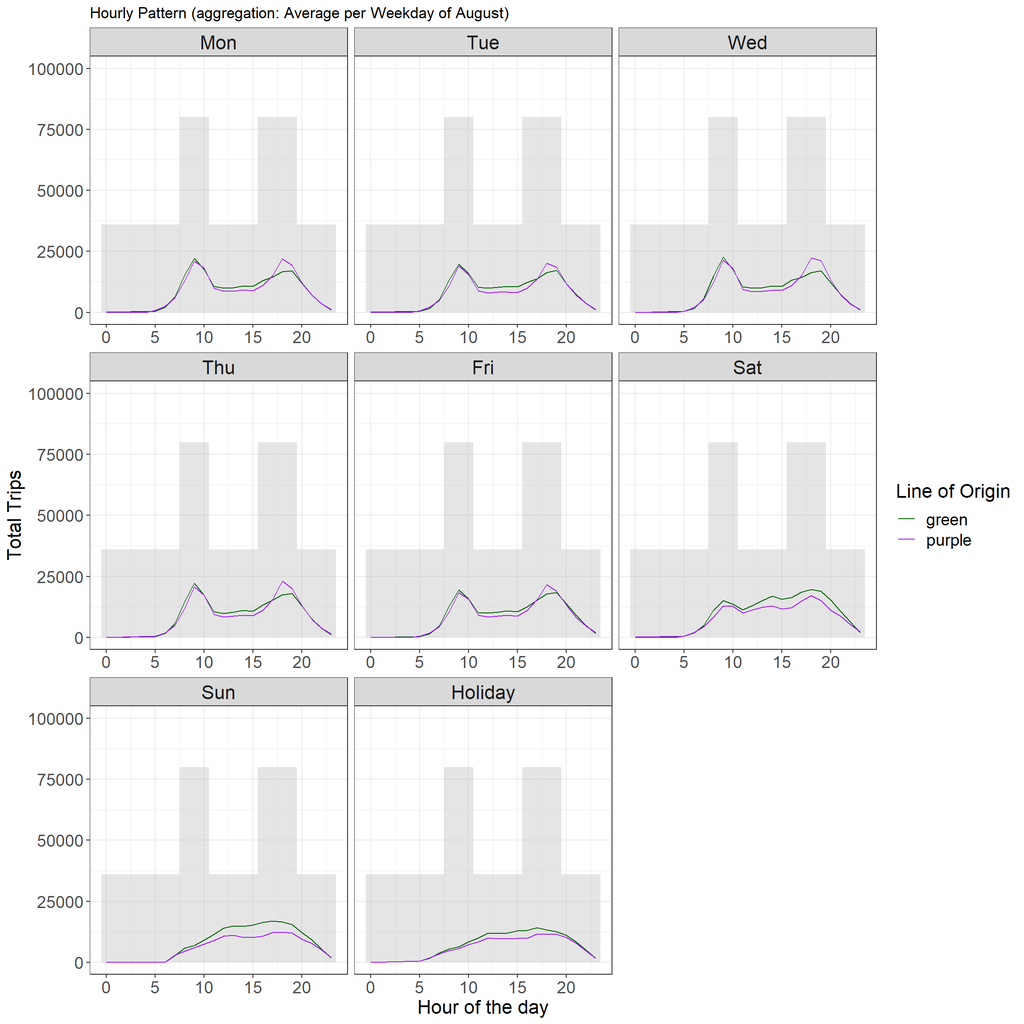

# 4 Line Based Characteristics - Whole Month

Sample Calculation for Monday: Add all trips on all Mondays of the month.

## 4.1 Hourly Trends: Smart Cards

The public holidays include Independence Day (15), Ganesh Chaturthi (31).

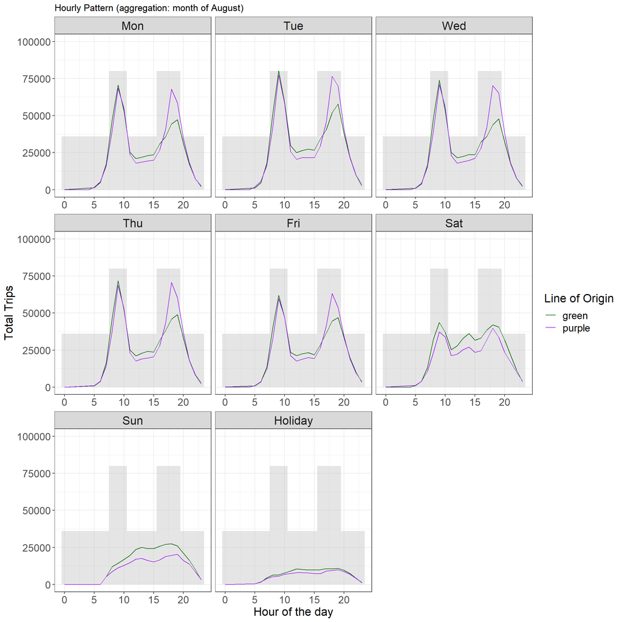

## 4.2 Hourly Trends: Tokens

The public holidays include Independence Day (15), Ganesh Chaturthi (31).

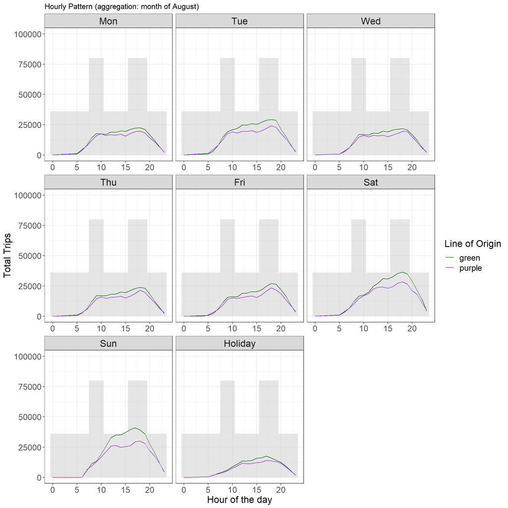

## 4.3 Hourly Trends: Smart Cards + Tokens

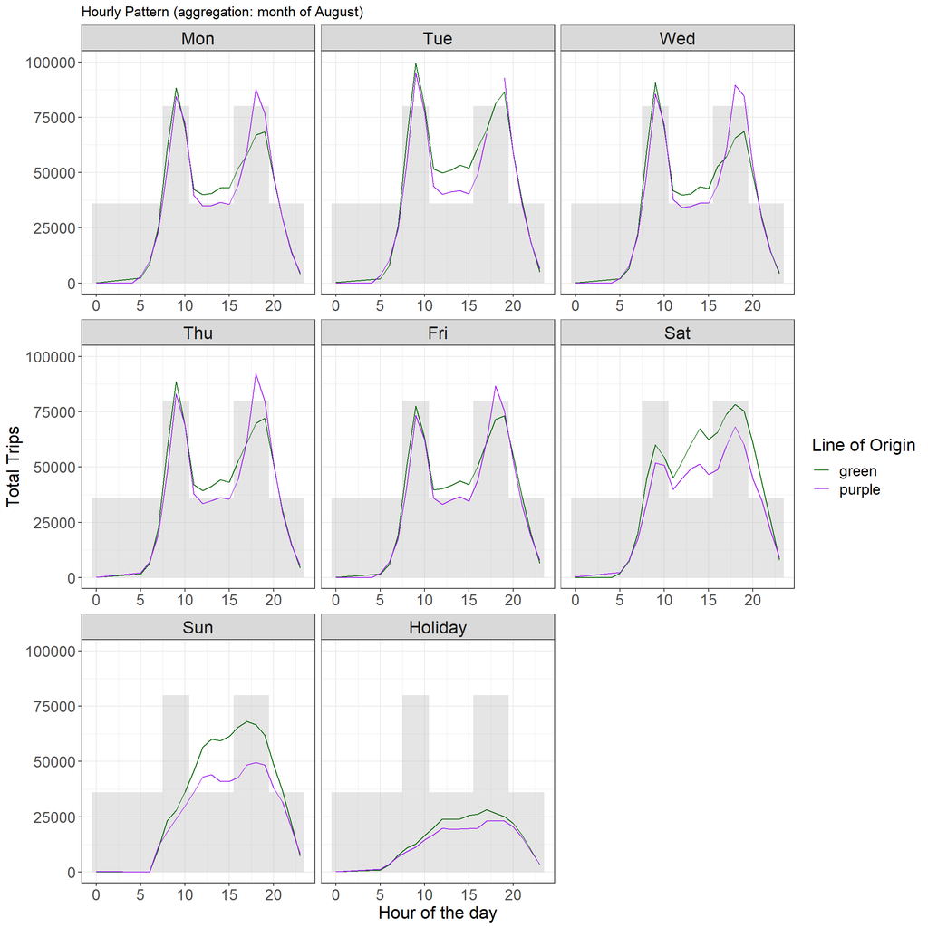

## 4.4 Peak vs Off Peak: Smart Cards+Tokens

Morning Peak is 08:00-10:00 hrs, Evening Peak is 16:00-19:00 hrs

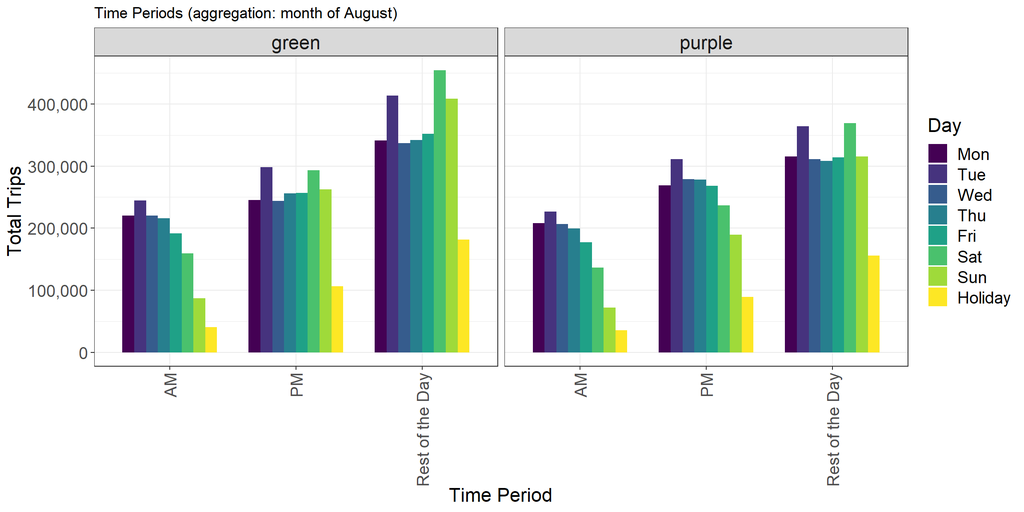

## 4.5 Peak vs Off Peak: Smart Cards

Morning Peak is 08:00-10:00 hrs, Evening Peak is 16:00-19:00 hrs

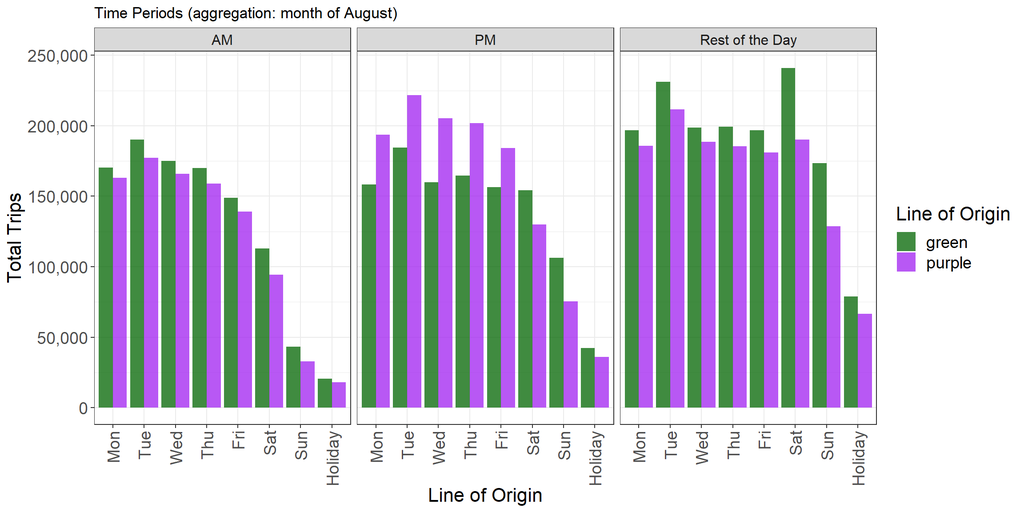

## 4.6 Peak vs Off Peak: Tokens

Morning Peak is 08:00-10:00 hrs, Evening Peak is 16:00-19:00 hrs

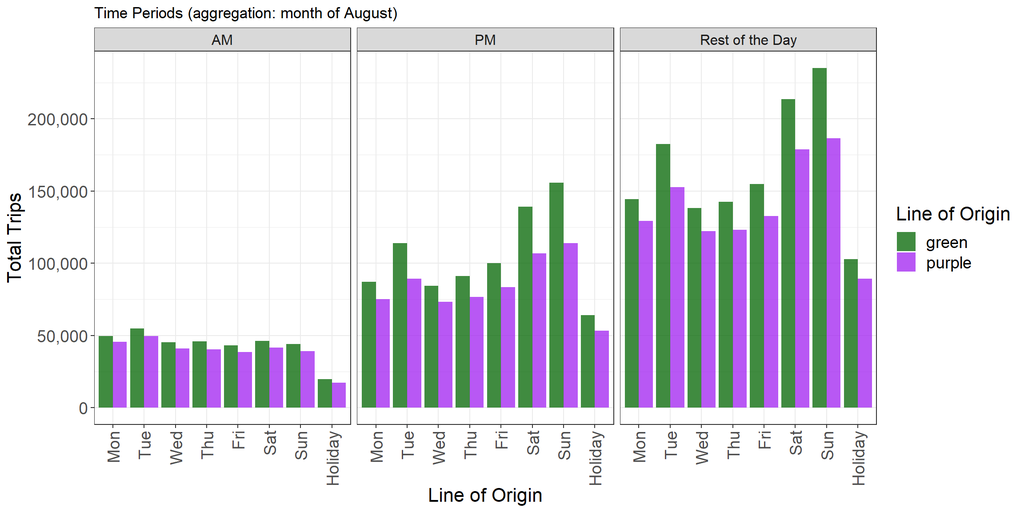

# 5 Stops’ Spacing Distribution

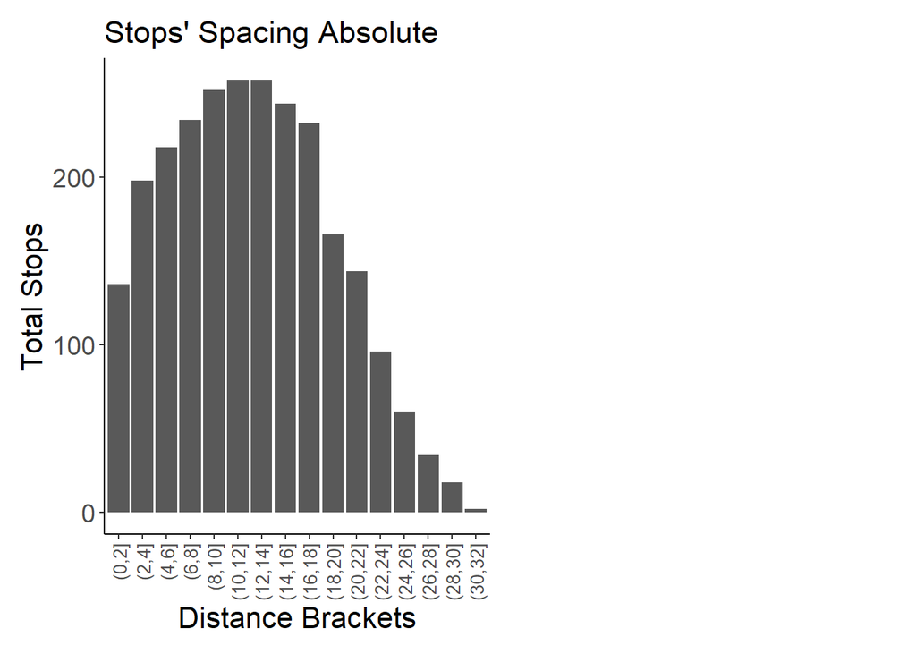

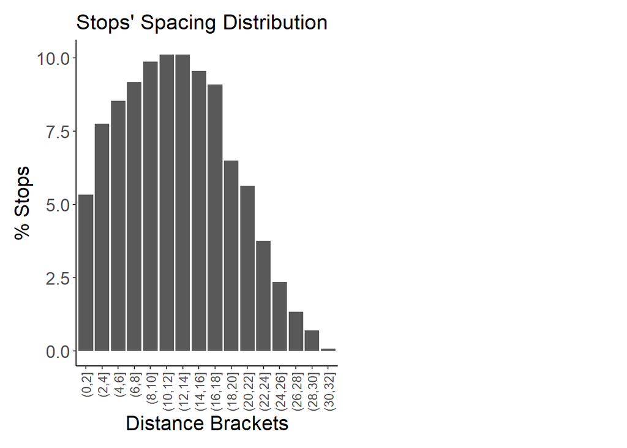

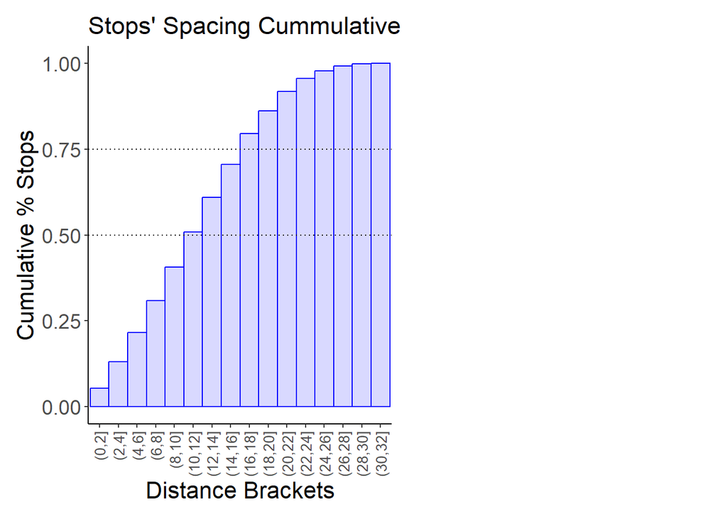

# 6 Trip Length Distribution

## 6.1 System

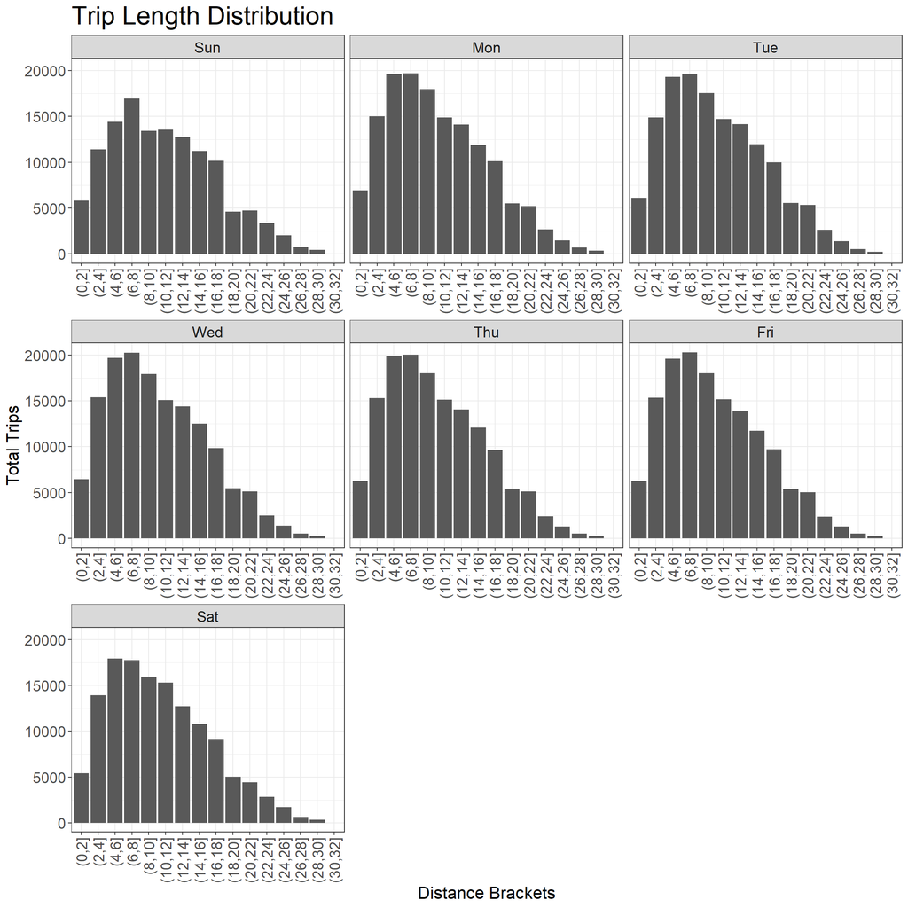

## 6.2 Line-wise

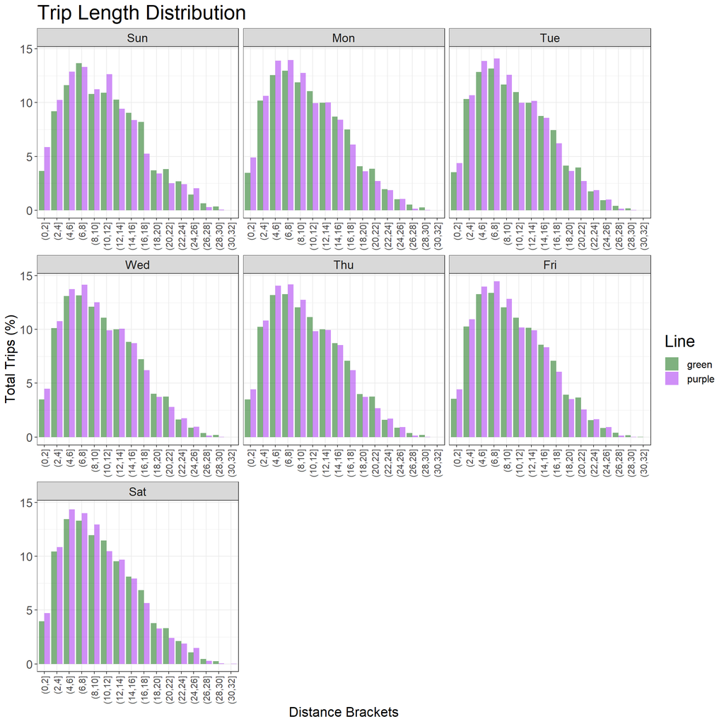

## 6.3 Smart Cards

[figure not shown]

## 6.4 Tokens

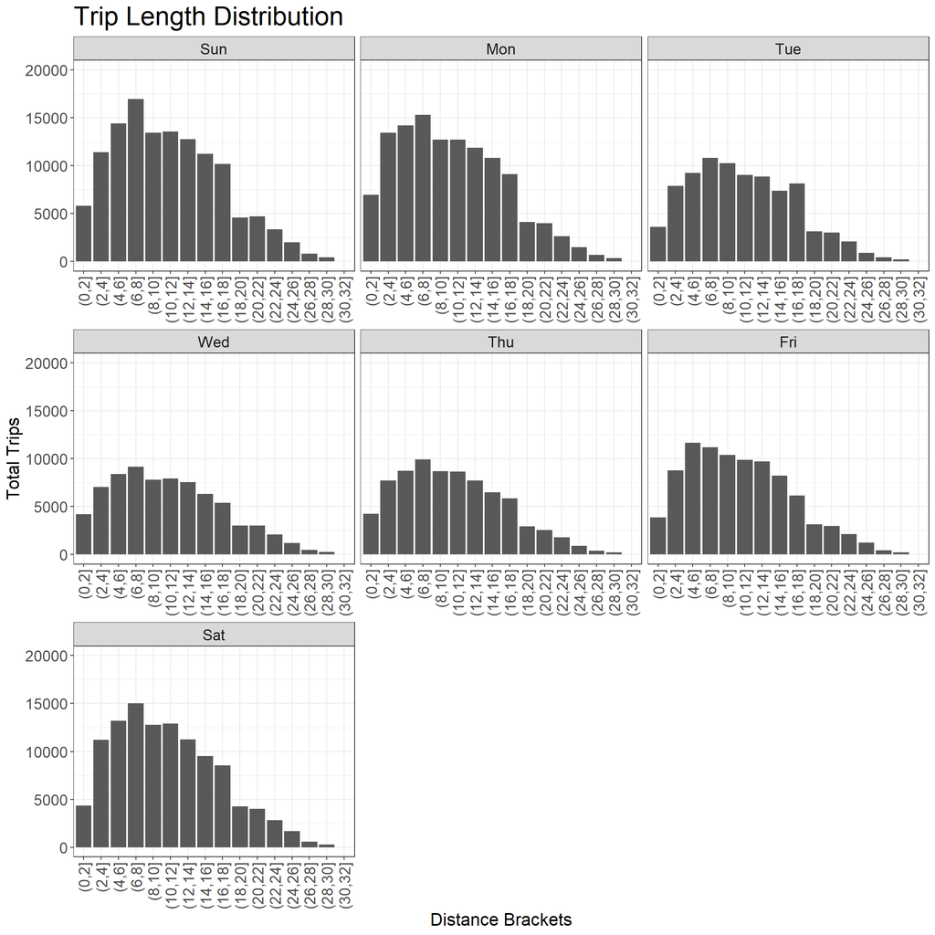

# 7 Peak flows on weekdays

- Morning Peak Hour for the map is 9-10am and Evening Peak Hour 6-7pm

## 7.1 Morning Peak Hour Flows

[interactive chart not shown]

## 7.2 Evening Peak Hour Flows

[interactive chart not shown]